# CLOC LCA Analysis

## The result is a conditional item response (column) probabilities, by outcome variable per class (row).

Generate table showing fitvalues of multiple models:

```r
set.seed(01012)
lc1<-poLCA(f, data=mydata, nclass=1, na.rm = FALSE, nrep=30, maxiter=3000) #Loglinear independence model.
lc2<-poLCA(f, data=mydata, nclass=2, na.rm = FALSE, nrep=30, maxiter=3000)
lc3<-poLCA(f, data=mydata, nclass=3, na.rm = FALSE, nrep=30, maxiter=3000)
lc4<-poLCA(f, data=mydata, nclass=4, na.rm = FALSE, nrep=30, maxiter=3000)
lc5<-poLCA(f, data=mydata, nclass=5, na.rm = FALSE, nrep=30, maxiter=3000)
lc6<-poLCA(f, data=mydata, nclass=6, na.rm = FALSE, nrep=30, maxiter=3000)
```

Calculate the Entropy (a pseudo-r-squared) for each solution:

```r
entropy<-function (p) sum(-p*log(p))
results$R2_entropy
```

```r
results[1,8]<-c("-")
error_prior<-entropy(lc2$P) # class proportions model 2
error_post<-mean(apply(lc2$posterior,1, entropy),na.rm = TRUE)
results[2,8]<-round(((error_prior-error_post) / error_prior),3)
error_prior<-entropy(lc3$P) # class proportions model 3
error_post<-mean(apply(lc3$posterior,1, entropy),na.rm = TRUE)
results[3,8]<-round(((error_prior-error_post) / error_prior),3)
error_prior<-entropy(lc4$P) # class proportions model 4
error_post<-mean(apply(lc4$posterior,1, entropy),na.rm = TRUE)
results[4,8]<-round(((error_prior-error_post) / error_prior),3)
error_prior<-entropy(lc5$P) # class proportions model 5
error_post<-mean(apply(lc5$posterior,1, entropy),na.rm = TRUE)
results[5,8]<-round(((error_prior-error_post) / error_prior),3)
error_prior<-entropy(lc6$P) # class proportions model 6
error_post<-mean(apply(lc6$posterior,1, entropy),na.rm = TRUE)
results[6,8]<-round(((error_prior-error_post) / error_prior),3)
colnames(results)<-c("Model","log-likelihood","resid. df","BIC","aBIC","cAIC",
                     "likelihood-ratio","Entropy")
lca_results<-results
```

Generate a HTML-TABLE and show it in the RSTUDIO-Viewer (for copy & paste):

```r
view_kable <- function(x, ...){
  tab <- paste(capture.output(kable(x, ...)), collapse = '\n')
  tf <- tempfile(fileext = ".html")
  writeLines(tab, tf)
  rstudioapi::viewer(tf)
}
view_kable(lca_results, format = 'html', table.attr = "class=nofluid")
```

Another possibility which is prettier and easier to do:

```r
library("ztable")
ztable::ztable(lca_results)
```

Elbow-Plot (or Scree-Plot) can be used to see, which solution is parsimonius and has good fit-values. Order categories of results$model in order of appearance:

```r
library("forcats")
#results$model < - as_factor(results$model)
results2<-tidyr::gather(results,Criteria,Quality,4:7)                  #convert to long format
results2
```

```
      Model log-likelihood resid. df Entropy         Criteria   Quality
1  Modell 1      -7671.446      1398       -              BIC 16325.692
2  Modell 2      -6501.407      1263   0.181              BIC 14975.748
3  Modell 3      -5727.405      1128   0.104              BIC 14417.879
4  Modell 4      -5518.575       993   0.009              BIC 14990.353
5  Modell 5      -5325.848       858   0.006              BIC 15595.033
6  Modell 6      -5225.320       723       0              BIC 16384.112
7  Modell 1      -7671.446      1398       -             aBIC 15900.007
8  Modell 2      -6501.407      1263   0.181             aBIC 14121.202
9  Modell 3      -5727.405      1128   0.104             aBIC 13134.472
10 Modell 4      -5518.575       993   0.009             aBIC 13278.086
11 Modell 5      -5325.848       858   0.006             aBIC 13453.904
12 Modell 6      -5225.320       723       0             aBIC 13814.122
13 Modell 1      -7671.446      1398       -             cAIC 16459.692
14 Modell 2      -6501.407      1263   0.181             cAIC 15244.748
15 Modell 3      -5727.405      1128   0.104             cAIC 14821.879
16 Modell 4      -5518.575       993   0.009             cAIC 15529.353
17 Modell 5      -5325.848       858   0.006             cAIC 16269.033
18 Modell 6      -5225.320       723       0             cAIC 17193.112
19 Modell 1      -7671.446      1398       - likelihood-ratio 12103.848
20 Modell 2      -6501.407      1263   0.181 likelihood-ratio  9763.770
21 Modell 3      -5727.405      1128   0.104 likelihood-ratio  8215.766
22 Modell 4      -5518.575       993   0.009 likelihood-ratio  7798.107
23 Modell 5      -5325.848       858   0.006 likelihood-ratio  7412.652
24 Modell 6      -5225.320       723       0 likelihood-ratio  7211.597
```

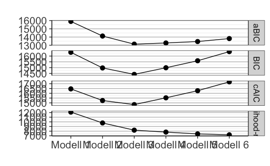

```r
fit.plot<-ggplot(results2) +
  geom_point(aes(x=Model,y=Quality),size=3) +
  geom_line(aes(Model, Quality, group = 1)) +
  theme_bw()+
  labs(x = "", y="", title = "") +
  facet_grid(Criteria ~. ,scales = "free") +
  theme_bw(base_size = 16, base_family = "") +
  theme(panel.grid.major.x = element_blank() ,
        panel.grid.major.y = element_line(colour="grey", size=0.5),
        legend.title = element_text(size = 16, face = 'bold'),
        axis.text = element_text(size = 16),
        axis.title = element_text(size = 16),
        legend.text=  element_text(size=16),
        axis.line = element_line(colour = "black"))
fit.plot
```

Network plot tries to visualize how classifications of observations (persons) in a latent class analysis change over a sequence of LC-models with growing number of classes. First, estimate 5 latent class models:

```r
f<-with(mydata, cbind(ANX1, ANX2, ANX3, DES, SHO1, SHO2, SHO3, ANG1, ANG2, ANG3, DES2, DES3, YEA1, YEA2, YEA3, RUM1, RUM2, RUM3, YEA4, DYS1, DYS2, APP1, APP2, SOM1, IRR1, IRR2, ANH, CON1, OBT1, OBT2, SOM2, LET, SUI1, SUI2, SUI3, SUI4)~1)
lc1<-poLCA(f, data=mydata, nclass=1, na.rm = FALSE, nrep=30, maxiter=3000) #Loglinear independence model.
```

```
Conditional item response (column) probabilities,
 by outcome variable, for each class (row)

$ANX1
           Pr(1)  Pr(2)  Pr(3)  Pr(4)
class 1:  0.6486 0.0691 0.1742 0.1081

$ANX2
           Pr(1)  Pr(2)  Pr(3)  Pr(4)
class 1:  0.6697 0.0511 0.1592 0.1201

$ANX3
           Pr(1) Pr(2)  Pr(3)  Pr(4)
class 1:  0.7568 0.048 0.1081 0.0871

$DES
           Pr(1) Pr(2)  Pr(3)  Pr(4)
class 1:  0.4054 0.048 0.2282 0.3183

$SHO1
           Pr(1) Pr(2)  Pr(3)  Pr(4)
class 1:  0.8018 0.033 0.0841 0.0811

$SHO2
           Pr(1) Pr(2)  Pr(3)  Pr(4)
class 1:  0.6727 0.039 0.1532 0.1351

$SHO3
           Pr(1) Pr(2)  Pr(3)  Pr(4)
class 1:  0.7508 0.039 0.1261 0.0841

$ANG1
           Pr(1)  Pr(2)  Pr(3)  Pr(4)
class 1:  0.7928 0.0571 0.0901 0.0601

$ANG2
           Pr(1) Pr(2)  Pr(3)  Pr(4)
class 1:  0.7297 0.048 0.1201 0.1021

$ANG3
```

[output cut: 111 more lines]

```
 1

=========================================================
Fit for 1 latent classes:
=========================================================
number of observations: 1532
number of fully observed cases: 333
number of estimated parameters: 134
residual degrees of freedom: 1398
maximum log-likelihood: -7671.446

AIC(1): 15610.89
BIC(1): 16325.69
G^2(1): 12103.85 (Likelihood ratio/deviance statistic)
X^2(1): 3.257707e+34 (Chi-square goodness of fit)
```

```r
lc2<-poLCA(f, data=mydata, nclass=2, na.rm = FALSE, nrep=30, maxiter=3000)
```

```
Model 1: llik = -6501.708 ... best llik = -6501.708
Model 2: llik = -6504.304 ... best llik = -6501.708
Model 3: llik = -6503.522 ... best llik = -6501.708
Model 4: llik = -6505.171 ... best llik = -6501.708
Model 5: llik = -6504.304 ... best llik = -6501.708
Model 6: llik = -6503.522 ... best llik = -6501.708
Model 7: llik = -6503.522 ... best llik = -6501.708
Model 8: llik = -6503.522 ... best llik = -6501.708
Model 9: llik = -6503.522 ... best llik = -6501.708
Model 10: llik = -6503.522 ... best llik = -6501.708
Model 11: llik = -6505.171 ... best llik = -6501.708
Model 12: llik = -6503.522 ... best llik = -6501.708
Model 13: llik = -6503.522 ... best llik = -6501.708
Model 14: llik = -6503.427 ... best llik = -6501.708
Model 15: llik = -6503.522 ... best llik = -6501.708
Model 16: llik = -6505.171 ... best llik = -6501.708
Model 17: llik = -6504.304 ... best llik = -6501.708
Model 18: llik = -6503.522 ... best llik = -6501.708
Model 19: llik = -6633.486 ... best llik = -6501.708
Model 20: llik = -6633.486 ... best llik = -6501.708
Model 21: llik = -6504.304 ... best llik = -6501.708
Model 22: llik = -6505.171 ... best llik = -6501.708
Model 23: llik = -6503.516 ... best llik = -6501.708
Model 24: llik = -6501.407 ... best llik = -6501.407
Model 25: llik = -6552.458 ... best llik = -6501.407
Model 26: llik = -7027.182 ... best llik = -6501.407
Model 27: llik = -6503.427 ... best llik = -6501.407
Model 28: llik = -6503.522 ... best llik = -6501.407
Model 29: llik = -6503.522 ... best llik = -6501.407
Model 30: llik = -6505.171 ... best llik = -6501.407
Conditional item response (column) probabilities,
 by outcome variable, for each class (row)

$ANX1
           Pr(1)  Pr(2)  Pr(3)  Pr(4)
class 1:  0.4320 0.0462 0.2295 0.2924
class 2:  0.7012 0.0746 0.1607 0.0634

$ANX2
           Pr(1)  Pr(2)  Pr(3)  Pr(4)
```

[output cut: 177 more lines]

```
 0.0424 0.9576

=========================================================
Fit for 2 latent classes:
=========================================================
number of observations: 1532
number of fully observed cases: 333
number of estimated parameters: 269
residual degrees of freedom: 1263
maximum log-likelihood: -6501.407

AIC(2): 13540.81
BIC(2): 14975.75
G^2(2): 9763.77 (Likelihood ratio/deviance statistic)
X^2(2): 1.673372e+19 (Chi-square goodness of fit)
```